# Lista 1 - Exercício B

Gustavo Tironi

10/05/2023

# 1 Escolha do gráfico

Inicialmente, a partir do material disponibilizado no **ECLASS** achei interessante o gráfico do Willian Playfair então pesquisei na internet e achei um gráfico feito em R, disponível [aqui](https://github.com/carloscinelli/Blog-Scripts) e mostrado a seguir:

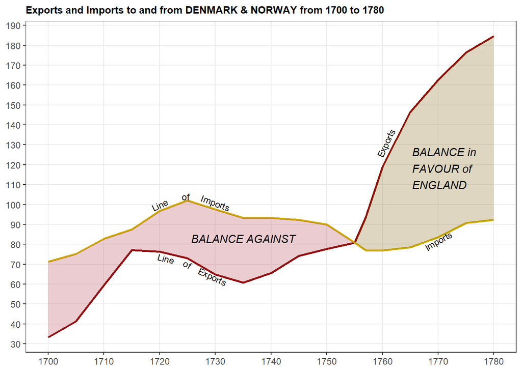

Vale pontuar que foram necessárias algumas mudanças no código original para que funcionasse corretamente, já que o mesmo contêm uma fonte de texto a qual não obtive acesso e possui alguns comandos que mudaram nas versões mais recentes do R.

# 2 Modificando o gráfico

Inicialmente, pensei em mudar o eixo para direita, pois é assim que o gráfico original é apresentado. Fiz isso, usando o seguinte código:

```
scale_y_continuous(position = "right")
```

Após isso, resolvi arrumar também a escala do eixo y, já que o original inicia do 0, enquanto o plotado em R começa do 30. Para isso, utilizei o seguinte comando:

```
scale_y_continuous(limits = c(10000, NA))
```

Após isso, fiz várias mudanças menores, como mudança no **título**, na **largura da linha**, na **posição dos textos** e nas **cores**. Ficando com o seguinte gráfico ao final das mudanças:

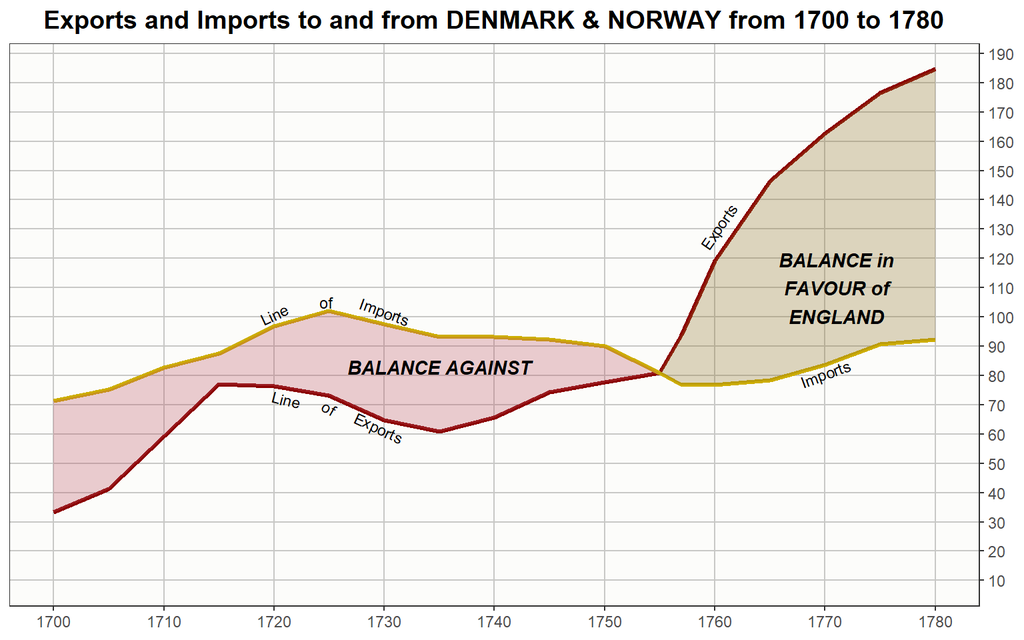

Por fim, resolvi adicionar informações ao gráfico, apenas com o fim de aprender alguns comandos novos em R. Então resolvi adicionar **linhas verticais** que separam o gráfico pelos reis que governavam em cada período. Para isso, eu precisava adicionar as **linhas verticais** nas datas adequadas, e indicar com um **texto** qual rei governava o período. Para adicionar as linhas adicionei variações do seguinte comando:

```
geom_vline(xintercept = (data de mudança do reinado), linetype = "dashed")
```

Agora para adicionar os textos, usei um comando que já tinha sido usado pelo autor original do gráfico, que é o **annotate**, variando os seus parâmetros. Ao final, o resultado foi o seguinte:

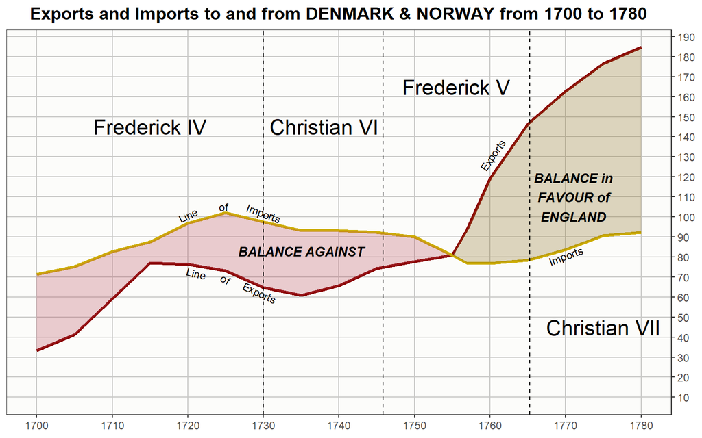

Sendo o código final o seguite:

```
library(reshape2)
library(ggplot2)
library(stats)

playfair <- readRDS("william_playfair.rds")

playfair$min <- with(playfair, pmin(exp, imp))
year <- playfair$year

molten_data <- melt(playfair,  id.vars = c("year", "min"))

ggplot(molten_data, aes(x = year, y = value)) +
  geom_line(aes(col = variable), size  = 1.1) +
  geom_ribbon(aes(ymin = min, ymax = value, fill = variable), alpha = 0.3) +
  scale_color_manual(values = c("darkred", "gold3"), guide = "none") +
  scale_fill_manual(values = c("#90752d", "#BB5766"), guide = "none") +
  theme_bw() +
  annotate("text", x = year[5],        y = 101000, label = "Line", angle = 25, size = 3) +
  annotate("text", x = year[6] - 100,  y = 105000, label = "of",  angle = 0, size = 3) +
  annotate("text", x = year[7],        y = 102000, label = "Imports", angle = 340, size = 3) +
  annotate("text", x = year[5] + 400,  y = 72000,  label = "Line",  angle = 345, size = 3) +
  annotate("text", x = year[6],        y = 69000,  label = "of",  angle = 330, size = 3) +
  annotate("text", x = year[7] - 200,  y = 62400,  label = "Exports",  angle = 335, size = 3) +
  annotate("text", x = year[8]+150,        y = 83000,  label = 'BALANCE AGAINST',  angle = 0, fontface = "bold.italic") +
  annotate("text", x = year[16] + 400, y = 110000, label = 'BALANCE in\nFAVOUR of\nENGLAND',  angle = 0, fontface = "bold.italic") +
  annotate("text", x = year[16],       y = 80800,  label = "Imports",  angle = 20, size = 3) +
  annotate("text", x = year[14] + 100, y = 131000, label = "Exports",  angle = 55, size = 3) +
  annotate("text", x = year[4],  y = 145000,  label = "Frederick IV", size = 6) +
  annotate("text", x = year[8]+1100,  y = 145000,  label = "Christian VI", size = 6) +
  annotate("text", x = year[12]+200,  y = 165000,  label = "Frederick V", size = 6) +
  annotate("text", x = year[17],  y = 45000,  label = "Christian VII", size = 6) +
  ggtitle("Exports and Imports to and from DENMARK & NORWAY from 1700 to 1780") +
  scale_x_date(breaks = seq(year[1], year[18], by = "10 years"),
               labels = format(seq(year[1], year[18], by = "10 years"), "%Y")) +
  scale_y_continuous(breaks = seq(0, 190e3, 10e3),
                     labels = seq(0, 190, 10),
                     position = "right",
                     limits = c(10000, NA)) +
  theme(title = element_text(size = 12, face = 'bold'),
        plot.title = element_text(hjust=0.5),
        axis.title = element_blank(),
        axis.text = element_text(),
        panel.grid.minor = element_blank(),
        panel.grid.major = element_line(color = "#c8c8c6"),
        panel.background = element_rect(fill = "#fcfcfa")) +
  geom_vline(xintercept = year[7], linetype = "dashed") +
  geom_vline(xintercept = year[10]+300, linetype = "dashed") +
  geom_vline(xintercept = year[15]+100, linetype = "dashed")
```